# Final Project

## Graph 1 narrative

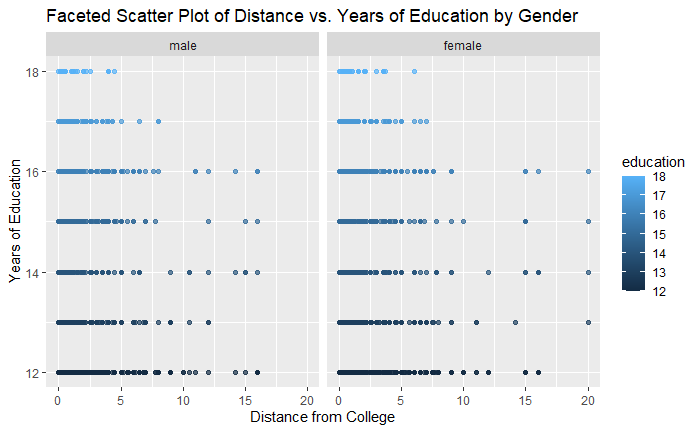

```r
# Faceted scatter plot
ggplot(CollegeDistance, aes(x = distance, y = education, color = education)) +
  geom_point(alpha = 0.7) +
  facet_wrap(~gender) +
  labs(title = "Faceted Scatter Plot of Distance vs. Years of Education by Gender",
       x = "Distance from College",
       y = "Years of Education")
```

##Creating Dummy Variable

$$FourYearCollege = \begin{cases} 1 &
\quad \text{if } education=16 \\ 0 & \quad \text{if }
education\not=16 \end{cases}$$
***In the United States, a four year college degree typically refers to a Bachelor’s degree. Therefore, in the context of the CollegeDistance data set provided, those who have been assigned 16 years of education can be referred to as having a four year college degree which are assign with 1 and others 0.

```r
CollegeDistance$FourYearCollege <- ifelse(CollegeDistance$education == "16", 1, 0)
head(CollegeDistance)
```

|  | gender | ethnicity | score | fcollege | mcollege | home | urban | unemp | wage | distance | tuition | education | income | region | FourYearCollege |
| --- | --- | --- | --- | --- | --- | --- | --- | --- | --- | --- | --- | --- | --- | --- | --- |
| 1 | male | other | 39.15 | yes | no | yes | yes | 6.2 | 8.09 | 0.2 | 0.88915 | 12 | high | other | 0 |
| 2 | female | other | 48.87 | no | no | yes | yes | 6.2 | 8.09 | 0.2 | 0.88915 | 12 | low | other | 0 |
| 3 | male | other | 48.74 | no | no | yes | yes | 6.2 | 8.09 | 0.2 | 0.88915 | 12 | low | other | 0 |
| 4 | male | afam | 40.40 | no | no | yes | yes | 6.2 | 8.09 | 0.2 | 0.88915 | 12 | low | other | 0 |
| 5 | female | other | 40.48 | no | no | no | yes | 5.6 | 8.09 | 0.4 | 0.88915 | 13 | low | other | 0 |
| 6 | male | other | 54.71 | no | no | yes | yes | 5.6 | 8.09 | 0.4 | 0.88915 | 12 | low | other | 0 |

### Empirical Models

#1. Does distance from a four-year college predict a student’s decision to attend a four-year college?

$$P(Y=1) = \beta_0+ \beta_1Distance+
\cdots +\beta_K X_K$$

#P(Y=1) is the probability outcome variable (decision to attend a fouryear college). #β0is the intercept. #β1 is the coefficient associated with the distance variable. #βk is the coefficient associated with the Xk variable.

##Assumptions:

#1. The relationship between the log-odds of the dependent variable and the independent variable (Distance in this case) is linear.

#2. Observations are independent of each other.

#3 The independent variable (Distance) is not a perfect linear combination of other independent variables.

#4. No extreme outliers are influencing the model excessively.

#5. The variance of the residuals is constant across all levels of the independent variable.

##2.Does distance from a four-year college affect a student’s overall number of years of education?

$$Y = \beta_0 + \beta_1Distance + \cdots
+\beta_K X_K+ \varepsilon$$

#Y is the overall number of years of education. #Distance is the distance from a four year college. #β0 is the intercept term. #β1 is the coefficient associated with the distance variable. #βk is the coefficient associated with the Xk variable. #ε is the error term.

##Assumptions:

#1. There is a linear relationship between the independent variable (Distance) and the dependent variable (Overall number of years of education).

#2. The residuals (the differences between observed and predicted values) are independent of each other.

#3. For homoscedasticity, the variance of the residuals is constant across all levels of the independent variable.

#4. The residuals are approximately normally distributed.

#5. The independent variable is not a perfect linear combination of other independent variables (No perfect multicollinearity).

#6.No extreme outliers influencing the model excessively.

### Linear Probability Regression for Empirical model 1:

```r
lpm<-lm(FourYearCollege~distance+tuition+ethnicity+income+mcollege+gender+score+wage+home+ urban+unemp+fcollege+region, data=CollegeDistance)
covHC<-vcovHC(lpm,type = "HC1")
robust_se<-sqrt(diag(covHC))
F_stat<-waldtest(lpm,vcov=covHC)

stargazer(lpm,lpm,type = "text",
                     se = list(NULL,robust_se),
                     omit.stat = "f",
                     add.lines = list(c("F Statistic (df = 11;1307)", "66.624***","36.865***"),c("Robust SE?","No","Yes")))
```

```
============================================================
                                    Dependent variable:
                                ----------------------------
                                      FourYearCollege
                                     (1)            (2)
------------------------------------------------------------
distance                           0.00001        0.00001
                                   (0.003)        (0.002)

tuition                             0.017          0.017
                                   (0.022)        (0.020)

ethnicityafam                       0.007          0.007
                                   (0.016)        (0.015)

ethnicityhispanic                   0.020          0.020
                                   (0.015)        (0.015)

incomehigh                         0.064***      0.064***
                                   (0.013)        (0.014)

mcollegeyes                        0.071***      0.071***
                                   (0.018)        (0.021)

genderfemale                       0.029***      0.029***
                                   (0.011)        (0.011)

score                              0.012***      0.012***
                                   (0.001)        (0.001)

wage                                -0.007        -0.007
                                   (0.004)        (0.004)

homeyes                             0.010          0.010
                                   (0.014)        (0.013)

urbanyes                            0.009          0.009
                                   (0.014)        (0.014)

unemp                               0.002          0.002
                                   (0.002)        (0.002)

fcollegeyes                        0.058***      0.058***
                                   (0.016)        (0.018)

regionwest                         -0.039**      -0.039**
                                   (0.017)        (0.015)

Constant                          -0.449***      -0.449***
                                   (0.055)        (0.052)

------------------------------------------------------------
F Statistic (df = 11;1307)        66.624***      36.865***
Robust SE?                            No            Yes
Observations                        4,739          4,739
R2                                  0.112          0.112
Adjusted R2                         0.110          0.110
Residual Std. Error (df = 4724)     0.371          0.371
============================================================
Note:                            *p<0.1; **p<0.05; ***p<0.01
```

## Interpretation of results

#The linear probability model (LPM) was used to estimate the effect of various independent variables on the probability of attending a four year college. In an LPM, the dependent variable is binary (in this case, whether or not someone attends a four year college), and the coefficients represent the change in the probability of the event occurring (attending a four year college) for a one unit change in the independent variable, holding all other variables constant.

#The coefficient of distance (0.00001) is very small and not statistically significant in either model. This implies that changes in distance have an insignificant impact on the probability of attending a four year college.

#Income has a coefficient of 0.064 which is statistically significant at the 1% level in both models, indicating that a high income increases the probability of attending a four year college by about 6.4% holding all other vairables constant.

#Having a mother who attended college increases the probability of attending a four year college by 7.1% ceteris paribos.

#Being female increases the probability of attending a four year college by about 2.9% compared to males ceters paribos.

#Score’s coefficient is 0.012 and is statistically significant at the 1% level in both models. This suggests that for each one unit increase in the score, the probability of attending a four year college increases by 1.2% holding other factors constant.

#The father college Yes has a coefficient of 0.058, suggesting that having a father who attended college increases the probability of attending a four year college by about 5.8% when other variables are held constant.

#The Region West with coefficient -0.039 is statistically significant at the 5% level, indicating that being from the western region reduces the probability of attending a four year college by about 3.9% ceteris paribos.

#Home Yes, Urban Yes, Unemp and wage: These variables are not statistically significant, indicating that they do not significantly influence the probability of attending a fouryear college. variables are not statistically significant at conventional levels in either model, suggesting they do not have a reasonable impact on the probability of attending a four year college.

#The R-squared value of 0.112 indicate that the model explains about 11.2% of the variability in the likelihood of attending a four year college.

## Linear Regression

```r
library(lmtest)
reg <- lm(education ~ distance + tuition + score + ethnicity + wage + FourYearCollege + fcollege + urban + mcollege + unemp + fcollege + home + region + income + gender ,data = CollegeDistance)
stargazer(reg, type = "text")
```

```
===============================================
                        Dependent variable:
                    ---------------------------
                             education
-----------------------------------------------
distance                     -0.036***
                              (0.009)

tuition                      -0.245***
                              (0.076)

score                        0.063***
                              (0.002)

ethnicityafam                0.293***
                              (0.057)

ethnicityhispanic            0.275***
                              (0.054)

wage                          -0.021
                              (0.016)

FourYearCollege              2.177***
                              (0.051)

fcollegeyes                  0.428***
                              (0.055)

urbanyes                       0.022
                              (0.048)

mcollegeyes                  0.228***
                              (0.062)

unemp                        0.025***
                              (0.008)

homeyes                       0.124**
                              (0.050)

regionwest                    -0.103*
                              (0.059)

incomehigh                   0.243***
                              (0.046)

genderfemale                  0.066*
                              (0.038)

Constant                     10.022***
                              (0.195)

-----------------------------------------------
Observations                   4,739
R2                             0.476
Adjusted R2                    0.475
Residual Std. Error      1.297 (df = 4723)
F Statistic         286.447*** (df = 15; 4723)
===============================================
Note:               *p<0.1; **p<0.05; ***p<0.01
```

## Interpretation

#In this linear regression model, the dependent variable is education. The coefficients represent the estimated change in the education level (measured in years) for a one unit change in each independent variable, holding all other variables constant.

#The intercept (Constant) is 10.022 representing the baseline level of education when all other variables are held constant or zero.

#The coefficient of distance is -0.036 which suggests that each additional unit of distance from the college (measured in 10 miles) is associated with a decrease of 0.036 years in education. The relationship is statistically significant at the 0.01 level.

#The coefficient of score is 0.063 indicates that, higher scores (perhaps standardized test scores or high school GPA) are significantly associated with an increase in years of education by 0.063 years.

#For unemp, small but statistically significant coefficient of 0.025 for unemployment suggests a positive association with years of education, which could imply that higher education levels might be pursued in times or areas of higher unemployment.

#The model’s R2 value of 0.476 indicates that approximately 47.6% of the variability in education levels can be explained by the included variables.

## Interactions

```r
attach(CollegeDistance)
interaction1<- FourYearCollege*tuition
interaction2<- unemp*wage
```

```r
reg1 <- lm(education ~ distance + interaction1 + score + ethnicity + interaction2 + fcollege + urban + mcollege + fcollege + home + region + income + gender ,data = CollegeDistance)
stargazer(reg1, type = "text")
```

```
===============================================
                        Dependent variable:
                    ---------------------------
                             education
-----------------------------------------------
distance                     -0.026***
                              (0.009)

interaction1                 2.136***
                              (0.057)

score                        0.066***
                              (0.003)

ethnicityafam                0.319***
                              (0.059)

ethnicityhispanic            0.380***
                              (0.054)

interaction2                  -0.0002
                              (0.001)

fcollegeyes                  0.422***
                              (0.057)

urbanyes                       0.051
                              (0.050)

mcollegeyes                  0.259***
                              (0.064)

homeyes                      0.145***
                              (0.052)

regionwest                   0.164***
                              (0.051)

incomehigh                   0.258***
                              (0.047)

genderfemale                  0.099**
                              (0.039)

Constant                     9.625***
                              (0.151)

-----------------------------------------------
Observations                   4,739
R2                             0.439
Adjusted R2                    0.437
Residual Std. Error      1.342 (df = 4725)
F Statistic         283.869*** (df = 13; 4725)
===============================================
Note:               *p<0.1; **p<0.05; ***p<0.01
```

## Interpretation with Interactions

#The expected education level is 9.625 represnt the intercept holding all other variables constant.

#For each unit increase in distance, there is a 0.026 unit decrease in the education level, holding other variables constant.

#A highly significant coefficient of 2.136 indicates a strong interaction effect between attending a four year college and tuition on the education level. This suggests that the relationship between attending a four-year college and education level varies depending on the level of tuition.

#The coefficient of score is 0.066 which implies that higher scores are associated with higher education levels.

#Both ethnicityafam and ethnicityhispanic have positive and significant coefficients of 0.319 and 0.380 respectively, indicating higher education levels compared to the base ethnicity group.

#Interaction2 is -0.0002 which is not statistically significant, suggesting that the interaction between unemployment and wage does not have a discernible impact on education level.

#Both fcollegeyes and mcollegeyes have significant positive effects on education level, indicating that having college educated parents is associated with higher education levels.

#The variables homeyes, regionwest, incomehigh, and genderfemale show significant positive effects, indicating various demographic factors that are associated with higher education levels.

#The R-squared value of 0.439 suggests that approximately 43.9% of the variability in the education level is explained by the model.

## Conclusion

#In the regression model with interactions, the baseline education level is 9.625 years. Distance decreases education by 0.026 years per unit. A significant interaction between four-year college attendance and tuition suggests variable education impact based on tuition levels. Higher scores increase education by 0.066 years. African American and Hispanic ethnicities have higher education levels than the base group (0.319 and 0.380 years more, respectively). The interaction between unemployment and wage is not significant. College-educated parents positively impact education levels. Home ownership, western region, high income, and being female are linked to higher education levels.The model explains about 43.9% of the variability in education levels.